# Quantitiative Fluorescence Curve Evaluation with Package `QurvE`

Nicolas T. Wirth

2022-12-20

**Please note:** This vignette will be updated from time to time when new features are implemented. Please find the most recent version at the [QurvE GitHub repository](https://github.com/NicWir/QurvE).

# Introduction

For a general introduction to the package, see the vignette *Quantitiative Growth Curve Evaluation with Package `QurvE`*. This vignette will show you how to use `QurvE` to analyze datasets with fluorescence measurements taken over time, as well as how to extract the most important results.

Fluorescent reporter proteins are widely used to study the mechanisms of gene regulation or to develop biosensors that allow the detection of chemical compounds and provide insights into the intracellular environment. A workflow for analyzing fluorescence data works analogously to analyzing growth data by following the scheme *read data* and *execute workflow*. The package allows users to select either time or growth data (e.g. from the simultaneous measurement of cell density and fluorescence intensity in plate reader experiments) as the independent variable. Additionally, biosensors can be characterized via dose-response analysis.

# Fluorescence profiling methods

`QurvE` offers the same curve evaluation methods for fluorescence data as for growth data, with the exception of fitting growth models. The calculation algorithms for *linear regression* and *nonparametric fits* (smoothing splines) as well as the default parameters have been empirically adjusted to account for the differences in curve shapes commonly seen with fluorescence data.

# Dose-response analysis methods

Dose response analysis is a useful method for evaluating the performance of a biosensor. Biosensors are typically designed to respond to specific chemical compounds, and the strength of the response often depends on the concentration of the target compound. Dose-response analysis can be used to determine the concentration of a target compound that elicits a half-maximal response in the biosensor (variants), the half-maximal effective concentration (EC<sub>50</sub>). This allows evaluation of the *sensitivity* and *specificity* of a biosensor and can be used to optimize the design for a particular application. In addition to evaluating the performance of biosensors, dose-response analysis can also be used to study the mechanisms of gene regulation in biological systems. By measuring the response of a biological system to different concentrations of a chemical compound, researchers can gain insights into the genes and pathways involved in the response, and can identify potential targets for drug discovery. `QurvE` provides two methods to perform dose-response analyses on fluorescence data:

1. Perform a smooth spline fit on response vs. concentration data and extract the *EC<sub>50</sub>* as the concentration at the midpoint between the largest and smallest response value.
2. Apply a biosensor response model to response vs. concentration data (Meyer *et al.*, 2019).

# Run a complete fluorescence analysis workflow

Load the package:

```r
library(QurvE)
```

Next, load your experimental data. In this example, the dataset being used is from a preliminary characterization of different versions of the SEVA (Standard European Vector Architecture) plasmid pSEVA634, as described in (Nikel *et al.*, 2022). The data contains both growth an fluorescence measurements that have been converted into the custom `QurvE` data format and are located in different work sheets of the same XLSX file:

## Load data

```r
input <- read_data(data.growth = system.file("lac_promoters.xlsx",
    package = "QurvE"), sheet.growth = 1, data.fl = system.file("lac_promoters.xlsx",
    package = "QurvE"), sheet.fl = 2, fl.normtype = "growth")  # normalize fluorescence to growth data
```

The two functions `read_data()` or `parse_data()` come with more arguments to give the user more control when loading fluorescence data. As for growth data, arguments `data.fl` (file path), `csvsep.fl` (separator symbol in CSV file), `dec.fl` (decimal separator), and `sheet.fl` (Excel file worksheet number or “name”) provide details on how where an how the data is stored. `calib.fl` allows defining an equation with which to transform fluorescence values.

Normalization of fluorescence, if any, can be controlled via `fl.normtype` to be performed by either dividing by growth values (`fl.normtype = 'growth'`) or fluorescence 2 `fl.normtype = 'fl2'`.

We can inspect the structure of the `input` object of class `grodata`:

```r
summary(input)
```

```
#>                   Length Class      Mode
#> time              1785   -none-     numeric
#> growth              88   data.frame list
#> fluorescence        88   data.frame list
#> norm.fluorescence   88   data.frame list
#> expdesign            4   data.frame list
```

## Plot raw data

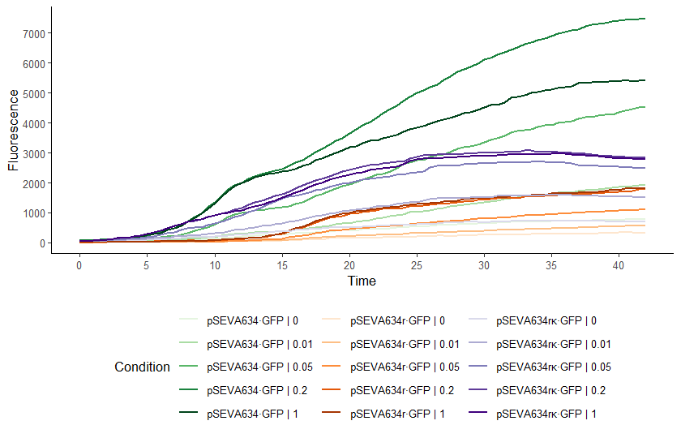

Raw data plot. Conditions can be selected or deselected using the `names = c('grp1', 'grp2')` argument or `exclude.nm = c('grp3', 'grp4')` argument, respectively. Similarly, concentrations can be (de-selected) via the `conc` and `exclude.conc` arguments. To plot individual samples instead of grouping replicates, add `mean = FALSE`. See `?plot.grodata` for further options.

```r
plot(input, data.type = "fl",
     exclude.conc = c(0.5, 0.1),
     log.y = FALSE,
     legend.position = "bottom",
     basesize = 10,
     legend.ncol = 3,
     lwd = 0.7)
```

## Run Workflow

```r
flFitRes <- fl.workflow(grodata = input,
    fit.opt = c("s", "l"),
    x_type = "time",
    norm_fl = TRUE,
    ec50 = TRUE,
    dr.parameter = "dY.spline",
    suppress.messages = TRUE,
    export.res = FALSE, # Prevent creating TXT table and RData files with results
    parallelize = FALSE) # Use only one available CPU core
```

If you want to create a report summarizing all computational results including a graphical representation of every fit, provide the desired output format(s) as `report = 'pdf'`, `report = 'html'`, or `report = c('pdf', 'html')`. The advantage of having the report in HTML format is that every figure can be exported as (editable) PDF file.

*In the spirit of good scientific practice (data transparency), I would encourage anyone using QurvE to attach the .RData file and generated reports to their publication.*

Arguments that are commonly modified:

| `fit.opt` | Which growth fitting methods to perform; a string containing `'l'` for linear fits or `'s'` for spline fits. Both fit types can be selected as a vector of strings: `c('l', 's').` |
| --- | --- |
| `x_type` | Data type used as independent variable. Either `'growth'` or `'time'`. |
| `norm_fl` | Use normalized fluorescence values for curve fitting (if `x_type = 'time'`). |
| `log.y.lin` `log.y.spline` | Should Ln(y/y0) be applied to the fluorescence data for the respective fits? |
| `biphasic` | Extract parameters for two different phases (as observed with, e.g., diauxic shifts) |
| `interactive` | Controls interactive mode. If `TRUE`, each fit is visualized in the Plots pane and the user can adjust fitting parameters and confirm the reliability of each fit per sample |
| `nboot.fl` | Number of bootstrap samples used for nonparametric curve fitting. See `?flBootSpline` for details. |
| `dr.method` | Define the method used to perform a dose-responde analysis: smooth spline fit (`'spline'`) or model fitting (`'model'`, the default). See section 4 |
| `dr.parameter` | The response parameter in the output table to be used for creating a dose response curve. See `?fl.drFit` for further details. |

Please consult `?fl.workflow` for further arguments to customize the workflow.

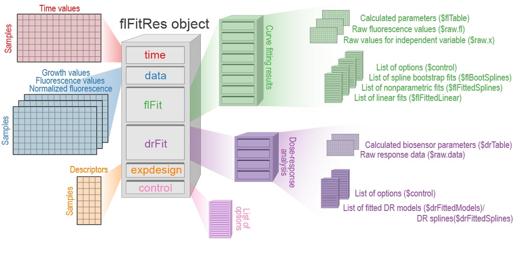

## Tabular results

A `flFitRes` object contains two tables summarizing the computational results: - `flFitRes$flFit$flable` lists all calculated curve parameters for every sample and fit - `flFitRes$drFit$drTable` contains the results of the dose-response analysis

Additionally, the dedicated functions `table_group_fluorescence_linear()` and `table_group_fluorescence_spline()` allow the generation of grouped results tables for the two fit types with averages and standard deviations. The column headers in the resulting data frames are formatted with HTML for visualization in shiny and with `DT::datatable()`.

A summary of results for each individual fit can be obtained by applying the generic function `summary()` to any fit object within `flFitRes`.

## Visualize results

### Inspect individual fits

It is important to verify the accuracy of the fits that have been applied before attempting to interpret any results (if the workflow is not run with `interactive = TRUE`. This is especially important when analyzing fluorescence data, as the curve shapes and the level of noise can vary significantly depending on the specific experiment and the equipment used for cultivation.

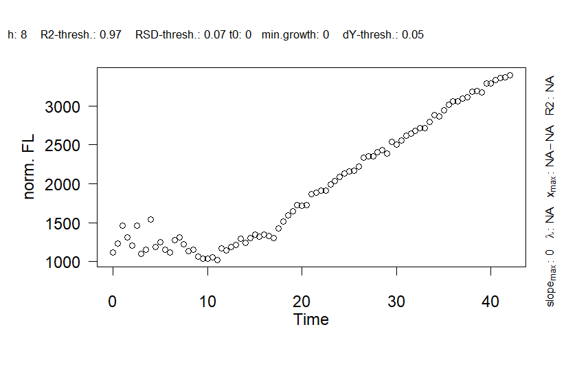

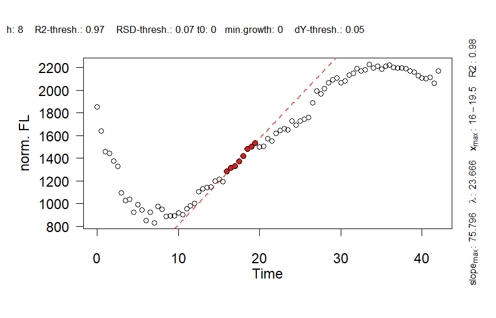

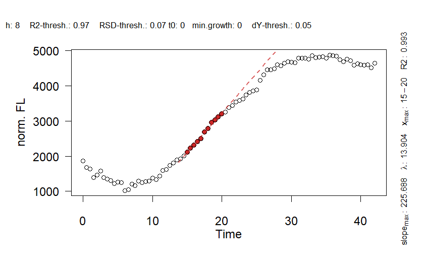

Linear fit plots to validate the applied fits. For details about this function, run `?plot.gcFitLinear`.

```r
plot(flFitRes$flFit$flFittedLinear[[1]], cex.lab = 1.2, cex.axis = 1.2)
plot(flFitRes$flFit$flFittedLinear[[3]], cex.lab = 1.2, cex.axis = 1.2)
plot(flFitRes$flFit$flFittedLinear[[6]], cex.lab = 1.2, cex.axis = 1.2)
```

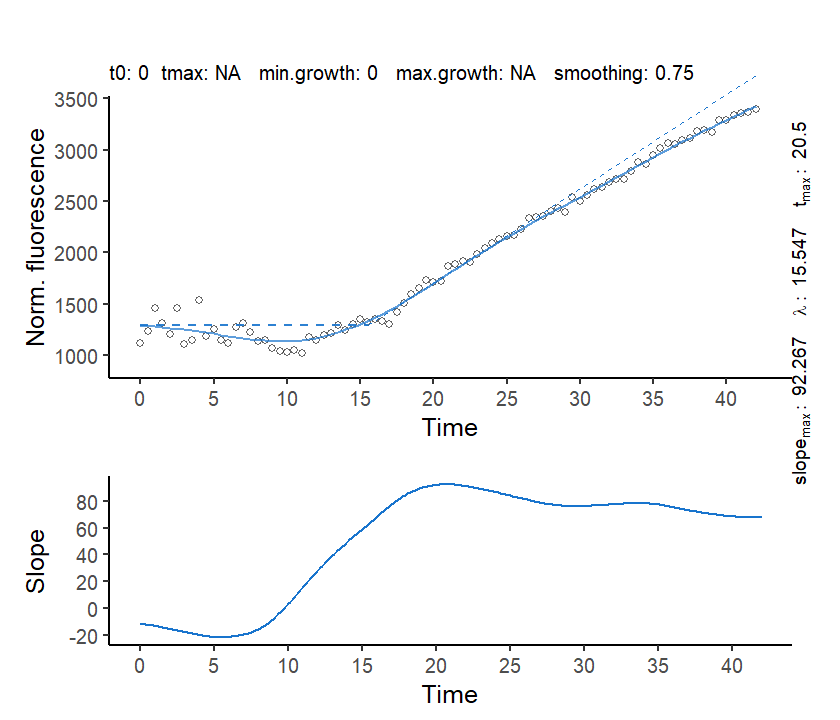

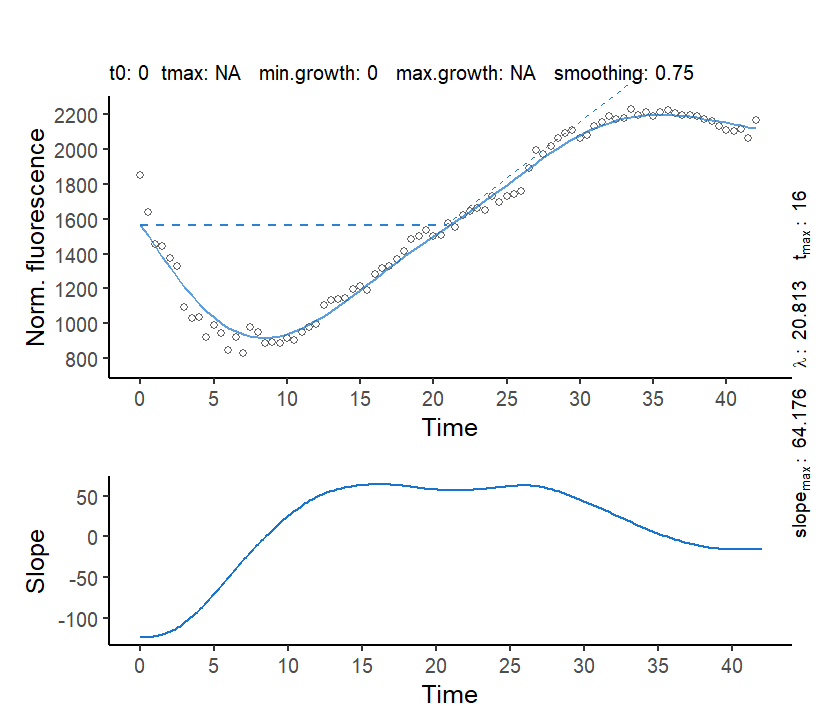

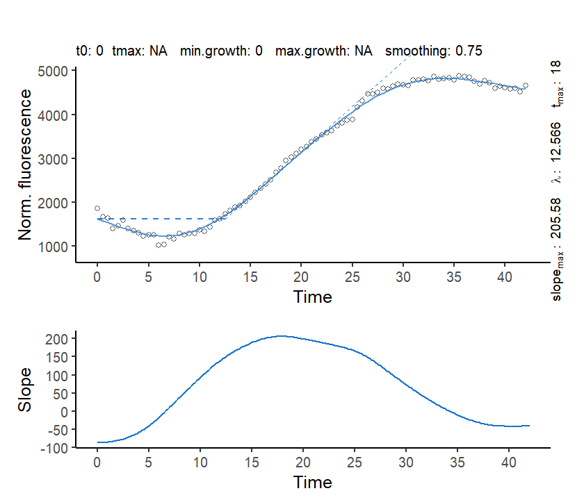

```r
plot(flFitRes$flFit$flFittedSpline[[1]], basesize = 15)
plot(flFitRes$flFit$flFittedSpline[[3]], basesize = 15)
plot(flFitRes$flFit$flFittedSpline[[6]], basesize = 15)
```

Normalization of fluorescence reads typically introduces additional noise. While the default smoothing parameter `smooth.fl` was suitable to produce good-quality representations of the curves via nonparametric fits, the linear fits either failed or produced regression windows that were too small. In order to obtain linear regression results that accurately represent the linear-increase section of the curves, we have to decrease the R2 threshold and manually increase the size of the sliding window (by default calculated automatically for each sample). These new settings need to be applied to all samples, so we re-run the entire workflow with adjusted parameters:

```r
flFitRes <- fl.workflow(grodata = input,
                          fit.opt = c("s", "l"),
                          x_type = "time",
                          norm_fl = TRUE,
                          lin.R2 = 0.95, # Decreased R2 threshold
                          lin.h = 20, # Manually defined sliding window size
                          ec50 = TRUE,
                          dr.parameter = "dY.spline",
                          suppress.messages = TRUE,
                          export.res = FALSE,
                          parallelize = FALSE)
```

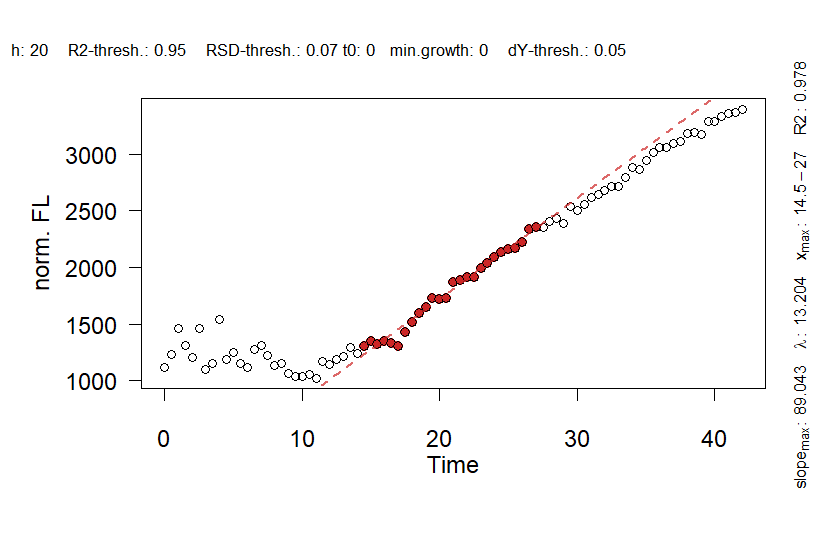

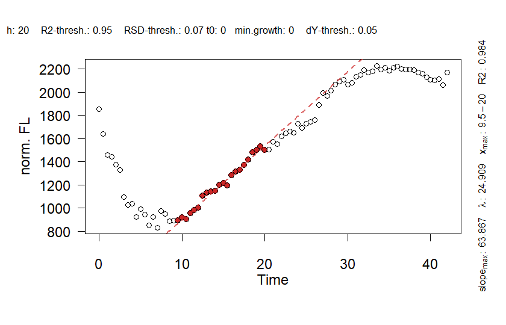

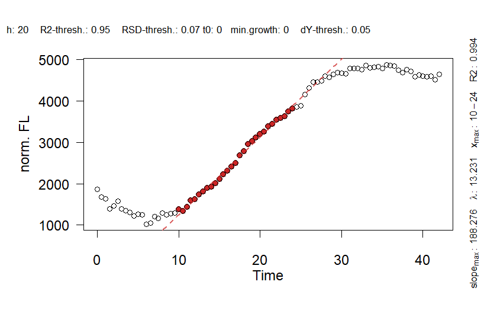

Linear fit plots to validate the linear regressions after re-running the workflow with adjusted parameters.

```r
plot(flFitRes$flFit$flFittedLinear[[1]], cex.lab = 1.2, cex.axis = 1.2)
plot(flFitRes$flFit$flFittedLinear[[3]], cex.lab = 1.2, cex.axis = 1.2)
plot(flFitRes$flFit$flFittedLinear[[6]], cex.lab = 1.2, cex.axis = 1.2)
```

### Grouped spline fits

Applying `plot()` to the `flFitRes` object produces a figure of all spline fits performed as well as the first derivative (slope) over time. The generic function calls `plot.flFitRes()` with `data.type = 'spline'`.

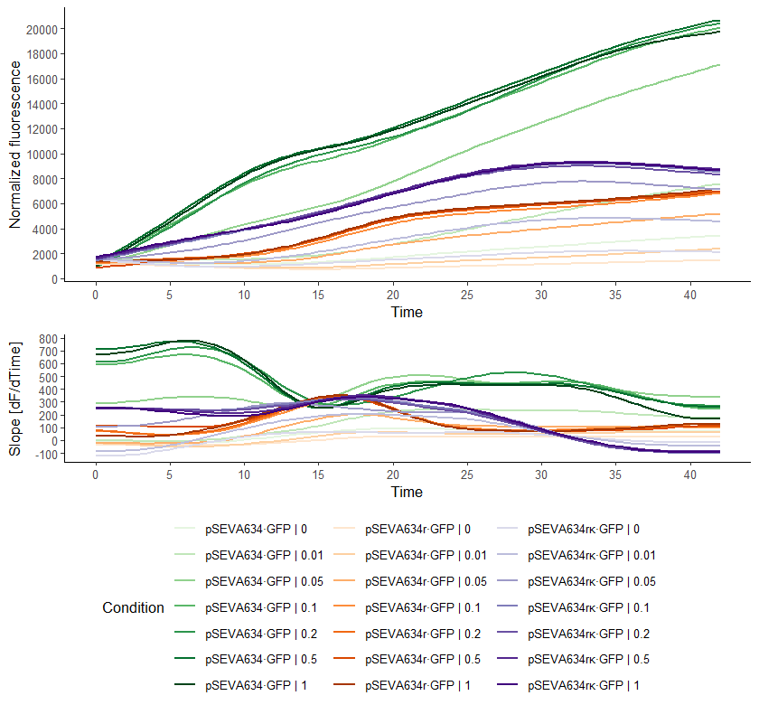

Combined plot of all spline fits performed. In addition to the options available with `data.type = 'raw'`, further arguments can be defined that control the appearance of the secondary panel showing the slope over time. See `?plot.flFitRes` for all options.

```r
plot(flFitRes,
     data.type = "spline",
     deriv = TRUE,
     legend.position = "bottom",
     legend.ncol = 3,
     n.ybreaks = 10,
     basesize=10,
     lwd = 0.7)
```

By arranging the individual samples in a grid, we can create a visual representation similar to a heat map that illustrates the values of a chosen parameter. This can be a helpful way to gain insights and understand trends within the data.:

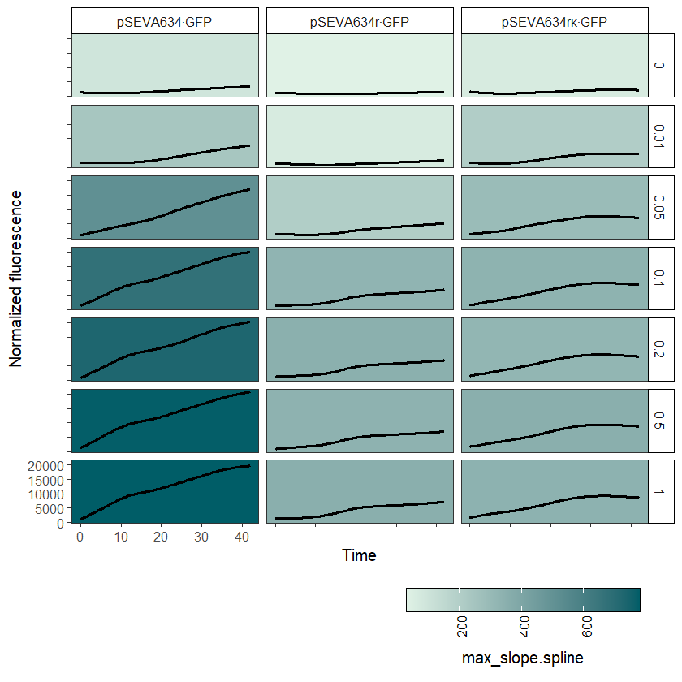

Plot grid of all spline fits performed with one concentration per row. See `?plot.grid` for available options.

```r
plot.grid(flFitRes,
          param = "max_slope.spline",
          pal = "Mint",
          log.y = FALSE,
          basesize = 12)
```

### Compare growth parameters

The function `plot.parameter()` works also on `flFitRes` objects to compare computed curve parameters:

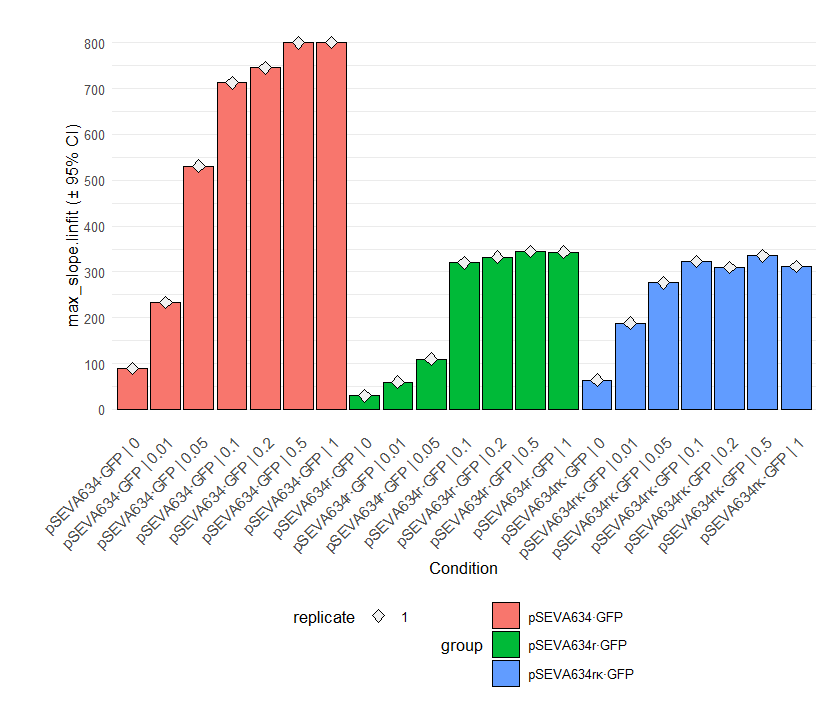

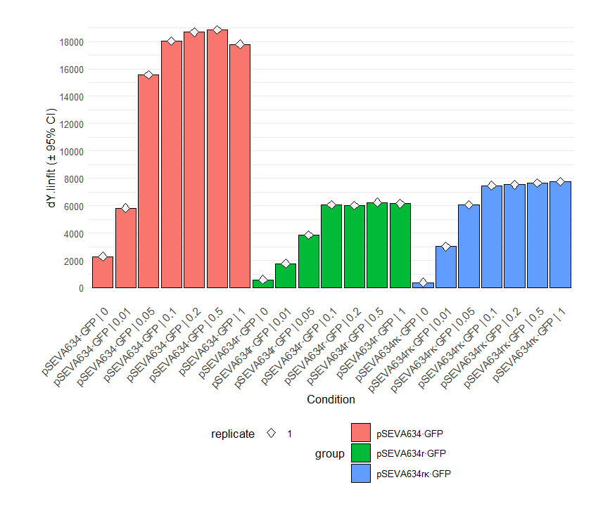

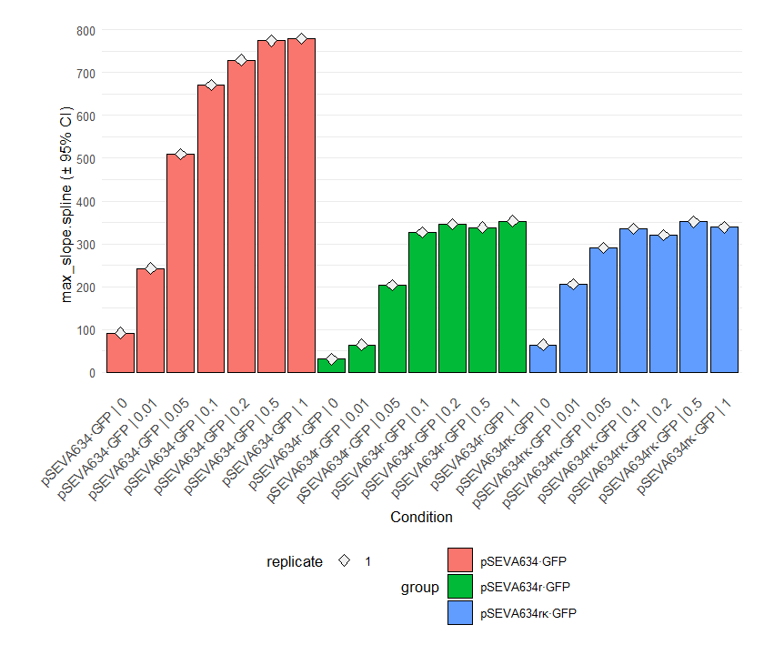

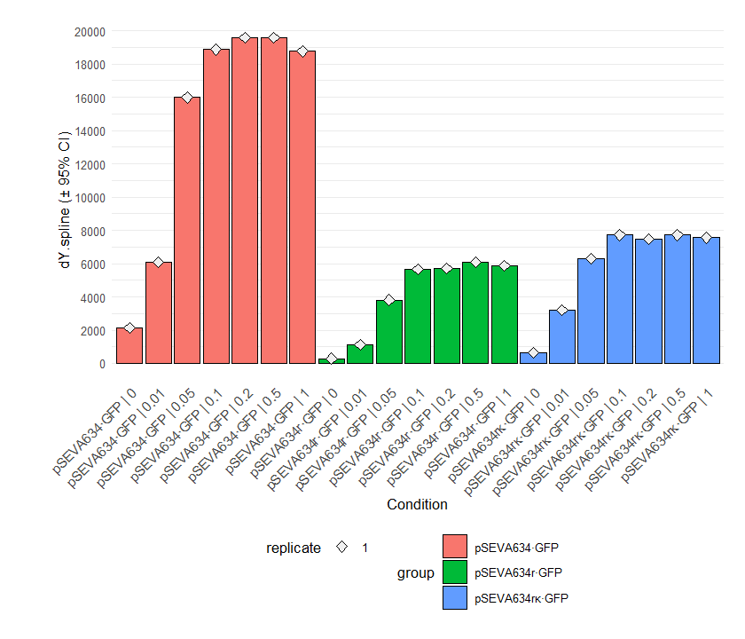

```r
# Parameters obtained from linear regression
plot.parameter(flFitRes, param = "max_slope.linfit", basesize = 10,
    legend.position = "bottom")
plot.parameter(flFitRes, param = "dY.linfit", basesize = 10,
    legend.position = "bottom")

# Parameters obtained from nonparametric fits
plot.parameter(flFitRes, param = "max_slope.spline", basesize = 10,
    legend.position = "bottom")
plot.parameter(flFitRes, param = "dY.spline", basesize = 10,
    legend.position = "bottom")
```

### Dose-response analysis

The results of the dose-response analysis can be visualized by calling `plot()` on the `drFit` object that is stored within `flFitRes`. This action calls `plot.drFit()` which in turn runs `plot.drFitSpline()` or `plot.drFitModel()` (depending on the choice of in the workflow) on every condition for which a dose-response analysis has been performed. Alternatively, you can call `plot()` on the list elements in `grofit$drFit$drFittedModels` or `grofit$drFit$drFittedSplines`, respectively.

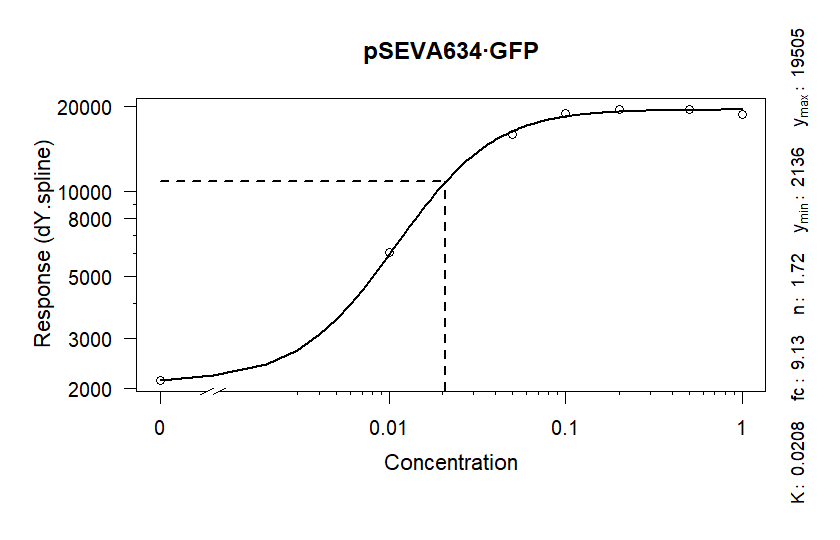

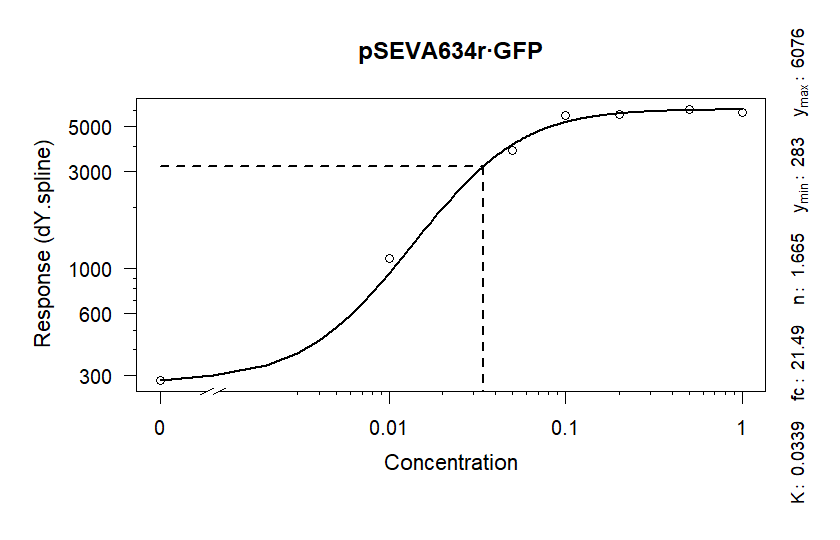

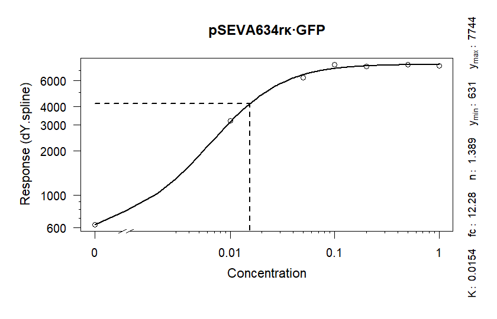

Dose response analysis - model fits. For details about this function, run `?plot.drFit`.

```r
plot(flFitRes$drFit, cex.point = 1, cex.lab = 1.1, cex.axis = 1)
```

# References

Meyer A.J., Segall-Shapiro T.H., Glassey E., Zhang J. & Voigt C.A. (2019). Escherichia coli “marionette” strains with 12 highly optimized small-molecule sensors. Nature Chemical Biology 15 (2): 196–204. https://doi.org/10.1038/s41589-018-0168-3.

Nikel P.I., Benedetti I., Wirth N.T., Lorenzo V. de & Calles B. (2022). Standardization of regulatory nodes for engineering heterologous gene expression: a feasibility study. Microbial biotechnology 15 (8): 2250–2265. https://doi.org/10.1111/1751-7915.14063.